# Stat 202: Lecture 18/19 (covers pp. 192-211)

Nathan VanHoudnos  
11/7/2014

### Agenda

1. Homework comments
2. Lecture 18/19 (covers pp. 192-211)

### Homework #5 Comments

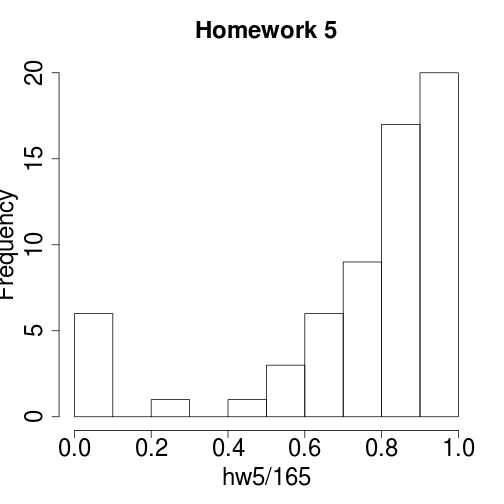

```r
mean(hw5/165)
```

```
[1] 0.7391053
```

```r
median(hw5/165)
```

```
[1] 0.8484848
```

One of the harder homeworks.

### Homework #5 comments

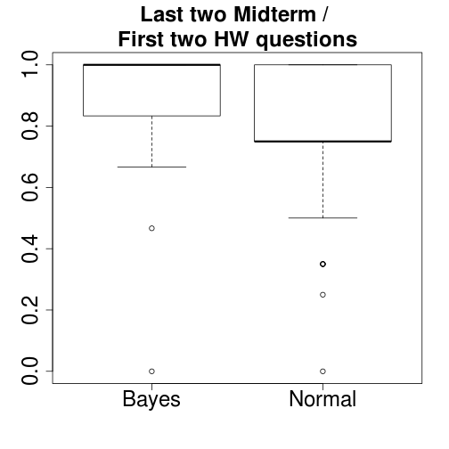

Students did much better than on the test!

I have posted solutions, as promised.

### Homework #5 comments

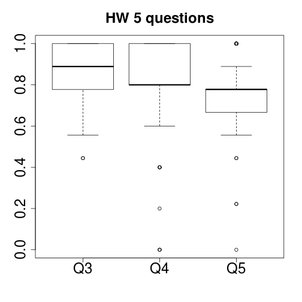

Here the most points were lost on Question 5.

- Many people missed the final question:

> What is the probability that the true value of 50 is in a 95% confidence interval? (10 pts)

### A perfect answer

> If we’re looking at a specific 95% confidence interval, the probability that the true value of 50 g is in there is either 0% or 100%.

> If we’re talking about 95% confidence intervals as a whole, we know that 95% of the time they contain the true population mean. If we drew a 95% confidence interval from a hat that contained 100 95% confidence intervals, 95% of the time we will draw a mean-containing interval.

> However, the probability that the mean is in the specific 95% confidence interval, due to the mean being a non-random value, is either 0% or 100%.

### A common misconception

A student wrote this:

> The probability that the true value of [the] mean is in a 95% confidence interval is 95% or 0.95.

Although the way the question was asked makes this response tempting, it is still **wrong**.

This question is a lot like the Obama question from Homework 2.

If I tempt you to say something false it is your duty to **hold the line**.

**You will see this again!**

### Agenda

1. Homework comments
2. Lecture 18/19 (covers pp. 192-211)

### Hypothesis testing overview

1. If \( H_0 \) is true, then over many experiments
   - 95% of **95% CIs** will contain the value assumed by \( H_0 \), and
   - 5% of **95% CIs** will not contain it.
2. Use this to our advantage:
   - **retain \( H_0 \)** if the CI contains the \( H_0 \) value, and
   - **reject \( H_0 \)** when it does not.
3. Therefore, for a 95% CI when \( H_0 \) is true:
   - 95% of **experiments** will **correctly retain \( H_0 \)**
   - 5% of **experiments** will **incorrectly reject \( H_0 \)**.

### The mistakes we can make

We must either **Retain \( H_0 \)** or **Reject \( H_0 \)**.

```r
             Retain H0   |  Reject H0
==========|==============|===============
          |              |
==========|==============|===============
          |              |
==========|==============|===============
```

### The mistakes we can make

We must either **Retain \( H_0 \)** or **Reject \( H_0 \)**.

If \( H_0 \) is true, then

```r
             Retain H0   |  Reject H0
==========|==============|===============
H0 true   |   Good!      |  MISTAKE!
==========|==============|===============
          |              |
==========|==============|===============
```

### The mistakes we can make

We must either **Retain \( H_0 \)** or **Reject \( H_0 \)**.

If \( H_0 \) is false, then

```r
             Retain H0   |  Reject H0
==========|==============|===============
H0 true   |   Good!      |  MISTAKE!
==========|==============|===============
H0 false  |   MISTAKE!   |  Good!
==========|==============|===============
```

### The mistakes we can make

We must either **Retain \( H_0 \)** or **Reject \( H_0 \)**.

The two mistakes have special names:

```r
             Retain H0    |  Reject H0
==========|===============|===============
H0 true   |  Good!        |  Type I error
==========|===============|===============
H0 false  | Type II error |  Good!
==========|===============|===============
```

> Note: Everything **thus far** has focused on \( H_0 \) being true. We will get to Type II error in detail later.

### Everyone makes mistakes, so why can't you?

Big Bird  
Sesame Workshop

Hypothesis testing is best understood as

- a formal way to make a **decision** such that
- you **control** the number of times you **falsely reject** \( H_0 \) when \( H_0 \) is, in fact, true.
- If everyone makes mistakes, let's control how often we make a **Type I error over the course of our careers**.

### An Example

The weight distribution of a Normally-Distributed\( ^{\text{TM}} \) potato is normally distributed with a mean of 50 grams and a standard deviation of 7 grams.

Dan wants to buy three new fields. He leases them for one season, grows his crop of Normally-Distributed\( ^{\text{TM}} \) potatoes, and plans to buy each field if its potatoes are growing “correctly”.

At the end of the season, Dan will take one 5 lbs bag from each field and performs a hypothesis test for each. What are \( H_0 \) and \( H_A \)?

\[ H_0 : \mu = 50 \quad \quad H_A: \mu \ne 50 \]

### An example

The weight distribution of a Normally-Distributed\( ^{\text{TM}} \) potato is normally distributed with a mean of 50 grams and a standard deviation of 7 grams.

\[ H_0 : \mu = 50 \quad \quad H_A: \mu \ne 50 \]

In all fields, the 5 lbs bag contains 49 potatoes. The average weight of the potatoes in each bag was:

- 47 grams for Field A,
- 48 grams for Field B, and
- 49 grams for Field C.

If Dan is willing to accept a 5% Type I error rate, which fields, if any, should he purchase?

### An example: Field A

**Step 1**: Calculate the confidence interval.

Since Dan is willing to accept a 5% Type I error rate, we calculate a 95% CI:

\[ \begin{aligned} \bar{x} \pm [2] \sigma/\sqrt{n} & = 47 \pm 2 \cdot 7/\sqrt{49} \\ & = 47 \pm 2 \end{aligned} \]

**Step 2**: Retain \( H_0 \) if the null hypothesis is contained in the confidence interval and reject if not.

The 95% CI for \( \mu \) is \( [45, 49] \). The null hypothesis is \( \mu = 50 \). The confidence interval **does not** contain the \( H_0 \) value. **We reject \( H_0 \)**.

### An example: Field B

**Step 1**: Calculate the confidence interval.

Since Dan is willing to accept a 5% Type I error rate, we calculate a 95% CI:

\[ \begin{aligned} \bar{x} \pm [2] \sigma/\sqrt{n} & = 48 \pm 2 \cdot 7/\sqrt{49} \\ & = 48 \pm 2 \end{aligned} \]

**Step 2**: Retain \( H_0 \) if the null hypothesis is contained in the confidence interval and reject if not.

The 95% CI for \( \mu \) is \( [46, 50] \). The null hypothesis is \( \mu = 50 \). The confidence interval **does** contain the \( H_0 \) value. **We retain \( H_0 \)**.

### An example: Field C

**Step 1**: Calculate the confidence interval.

Since Dan is willing to accept a 5% Type I error rate, we calculate a 95% CI:

\[ \begin{aligned} \bar{x} \pm [2] \sigma/\sqrt{n} & = 49 \pm 2 \cdot 7/\sqrt{49} \\ & = 49 \pm 2 \end{aligned} \]

**Step 2**: Retain \( H_0 \) if the null hypothesis is contained in the confidence interval and reject if not.

The 95% CI for \( \mu \) is \( [47, 51] \). The null hypothesis is \( \mu = 50 \). The confidence interval **does** contain the \( H_0 \) value. **We retain \( H_0 \)**.

### An example: Summary

\[ H_0 : \mu = 50 \quad \quad H_A: \mu \ne 50 \]

If Dan is willing to accept a 5% Type I error rate, which fields, if any, should he purchase?

The decisions were

- Field A (\( \bar{x} = 47 \) grams): **reject \( H_0 \)**
- Field B (\( \bar{x} = 48 \) grams): **retain \( H_0 \)**
- Field C (\( \bar{x} = 49 \) grams): **retain \( H_0 \)**

Dan buys Fields B and C, but does not buy Field A.

### Everyone makes mistakes, so why can't you?

Big Bird  
Sesame Workshop

Is hypothesis testing useful?

- If you have to make a decision, then **yes**.
  - Step 1: Pick \( H_0 \) and \( H_A \).
  - Step 2: Pick Type I error.
  - Step 3: **LATER** Minimize Type II error **LATER**
  - Step 4: Calculate a CI.
  - Step 5: **Retain \( H_0 \)** if its value is in CI, and **reject \( H_0 \)** if not.

### Everyone makes mistakes, so why can't you?

Big Bird  
Sesame Workshop

What can we use hypothesis testing for?

- any **sample mean** problem (potatoes!),
- any **sample proportion** problem, and
- a few other things too.

First, another example…

### Example 2

In 2003 a poll estimated that 64% of U.S. adults support the death penalty for a person convicted of murder. In a more recent poll, 675 out of 1,000 U.S. adults chosen at random were in favor of the death penalty for convicted murderers. Do the results of this poll provide evidence that the proportion of U.S. adults who support the death penalty for convicted murderers (\( p \)) changed between 2003 and the later poll?

**Step 1**: Pick \( H_0 \) and \( H_A \).

\( H_0: p = .64 \) and \( H_A: p \ne .64 \)

### Example 2

In 2003 a poll estimated that 64% of U.S. adults support the death penalty for a person convicted of murder. In a more recent poll, 675 out of 1,000 U.S. adults chosen at random were in favor of the death penalty for convicted murderers. Do the results of this poll provide evidence that the proportion of U.S. adults who support the death penalty for convicted murderers (\( p \)) changed between 2003 and the later poll?

**Step 2**: Pick Type I error (Trick question.)

Nothing in the problem gives us a Type I error.

If not given otherwise, assume the “traditional” value of 5%.

### A quick aside: Why 5%?

**RA Fisher**

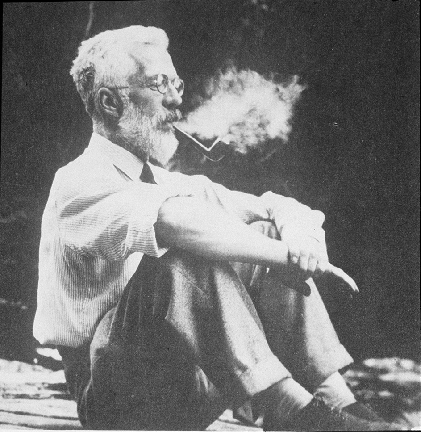

1890-1962

From his [Wikipedia page](http://en.wikipedia.org/wiki/Ronald_Fisher):

- “a genius who almost single-handedly created the foundations for modern statistical science”
- “the greatest biologist since Darwin” – Richard Dawkins

Fisher said that the Type I error should depend on the severity of making the error. He suggested 5% as a reasonable starting point.

### Example 2

In 2003 a poll estimated that 64% of U.S. adults support the death penalty for a person convicted of murder. In a more recent poll, 675 out of 1,000 U.S. adults chosen at random were in favor of the death penalty for convicted murderers. Do the results of this poll provide evidence that the proportion of U.S. adults who support the death penalty for convicted murderers (\( p \)) changed between 2003 and the later poll?

**Step 4**: Calculate a CI

(on board)

### Step 4 notes

**Step 4A**: Can we calculate a confidence interval, i.e. is \( \hat{p} \) normally distributed?

\[ n \hat{p} = 1000 \cdot 675/1000 = 675 \ge 10 \] \[ n (1- \hat{p}) = 1000 \cdot (1-675/1000) = 325 \ge 10 \]

Yes, both are greater than or equal to 10.

**Step 4B**: Use the formula

\[ \begin{aligned} \hat{p} \pm [2] \sqrt{\frac{\hat{p} (1 - \hat{p})}{n}} & = .675 \pm [2] \sqrt{\frac{.675 ( 1-.675)}{ 1000}} \\ & = .675 \pm 0.0296 \approx .675 \pm 0.03 \end{aligned} \]

### Example 2

In 2003 a poll estimated that 64% of U.S. adults support the death penalty for a person convicted of murder. In a more recent poll, 675 out of 1,000 U.S. adults chosen at random were in favor of the death penalty for convicted murderers. Do the results of this poll provide evidence that the proportion of U.S. adults who support the death penalty for convicted murderers (\( p \)) changed between 2003 and the later poll?

**Step 5**: **Retain \( H_0 \)** if its value is in CI, and **reject \( H_0 \)** if not.

The 95% CI for \( p \) is \( [.645, .705] \). \( H_0 \) assumes \( p = .64 \). We **reject \( H_0 \)**.

### Example 2: Summary

Do the results of this poll provide evidence that the proportion of U.S. adults who support the death penalty for convicted murderers (\( p \)) changed between 2003 and the later poll?

\[ H_0 : p = .64 \quad \quad H_A: p \ne .64 \]

The 95% CI for \( p \) is \( [.645, .705] \). \( H_0 \) assumes \( p = .64 \). We **reject \( H_0 \)**.

Therefore, the difference between the two polls is **statistically significant**.

### Everyone makes mistakes, so why can't you?

Big Bird  
Sesame Workshop

What I just taught:

- Step 1: Pick \( H_0 \) and \( H_A \).
- Step 2: Pick Type I error.
- Step 3: **LATER** Minimize Type II error **LATER**
- Step 4: Calculate a CI.
- Step 5: **Retain \( H_0 \)** if its value is in CI, and **reject \( H_0 \)** if not.

The book uses a different procedure that **gives the same decision** but is harder to interpret.

### How the book does it

Instead of picking a 5% Type I error rate and calculating a 95% confidence interval

\[ \bar{x} \pm [2] \sigma/\sqrt{n} \]

or picking some other pre-set \( \alpha \) as a Type I error rate and calculating a \( (1-\alpha) \times 100\% \) confidence interval

\[ \bar{x} \pm [z_{\alpha/2}] \sigma/\sqrt{n} \]

The book calculates the **p-value**.

### What is a p-value?

The **p-value** is defined as a conditional probability:

> The **p-value** is the conditional probability of, in the future, over many experiments, observing data at least as extreme as what was observed for this experiment given that the null hypothesis is true.

\[ P( \text{future data as extreme} | H_0 \text{ is true}) \]

### How to use a p-value

> The **p-value** is the conditional probability of, in the future, over many experiments, observing data at least as extreme as what was observed for this experiment given that the null hypothesis is true.

\[ P( \text{future data as extreme} | H_0 \text{ is true}) \]

If our acceptable Type I error is 5%, then we

- **reject \( H_0 \)** if the p-value is less than 5%
- **retain \( H_0 \)** if the p-value is greater than or equal to 5%.

Why? Let's look some examples…

### Examples

I run a study and calculate a p-value. If my p-value is .004 should I reject the null hypothesis at the 5% level?

I run a study and calculate a p-value. If my p-value is .25 should I reject the null hypothesis at the 5% level?

### Examples

I run a study and calculate a p-value. If my p-value is .004 should I reject the null hypothesis at the 0.3% level?

**No.** \( .004 \ge .003 \)

I run a study and calculate a p-value. If my p-value is .25 should I reject the null hypothesis at the 0.3% level?

**No.** \( .25 \ge .003 \)

### Example

The weight distribution of a Normally-Distributed\( ^{\text{TM}} \) potato is normally distributed with a mean of 50 grams and a standard deviation of 7 grams.

\[ H_0 : \mu = 50 \quad \quad H_A: \mu \ne 50 \]

In all fields, the 5 lbs bag contains 49 potatoes. The average weight of the potatoes in each bag was:

- 47 grams for Field A,
- 48 grams for Field B, and
- 49 grams for Field C.

### Example: Field A

The weight distribution of a Normally-Distributed\( ^{\text{TM}} \) potato is normally distributed with a mean of 50 grams and a standard deviation of 7 grams.

\[ H_0 : \mu = 50 \quad \quad H_A: \mu \ne 50 \]

If \( H_0 \) is true, then what is the probability of observing an average weight of 47 grams from a bag of 49 potatoes?

(on board)

### Example: Field B

The weight distribution of a Normally-Distributed\( ^{\text{TM}} \) potato is normally distributed with a mean of 50 grams and a standard deviation of 7 grams.

\[ H_0 : \mu = 50 \quad \quad H_A: \mu \ne 50 \]

If \( H_0 \) is true, then what is the probability of observing an average weight of 48 grams from a bag of 49 potatoes?

(on board)

### Example: Field C

The weight distribution of a Normally-Distributed\( ^{\text{TM}} \) potato is normally distributed with a mean of 50 grams and a standard deviation of 7 grams.

\[ H_0 : \mu = 50 \quad \quad H_A: \mu \ne 50 \]

If \( H_0 \) is true, then what is the probability of observing an average weight of 49 grams from a bag of 49 potatoes?

(on board)

### Example

The weight distribution of a Normally-Distributed\( ^{\text{TM}} \) potato is normally distributed with a mean of 50 grams and a standard deviation of 7 grams.

\[ H_0 : \mu = 50 \quad \quad H_A: \mu \ne 50 \]

In all fields, the 5 lbs bag contains 49 potatoes.

- Field A (\( \bar{x} = 47 \) grams): p-value of 0.003
- Field B (\( \bar{x} = 48 \) grams): p-value of 0.05
- Field C (\( \bar{x} = 49 \) grams): p-value of 0.32

If Dan can tolerate a Type I error of 5%, which fields (if any) should he buy?

### Example

If Dan can tolerate a Type I error of 5%, which fields (if any) should he buy?

- Field A p-value of \( 0.003 \)
  - Is \( 0.003 < .05? \) Yes, **Reject \( H_0 \)**.
- Field B p-value of \( 0.05 \)
  - Is \( 0.05 < .05? \) No, **Retain \( H_0 \)**
- Field C p-value of \( 0.32 \)
  - Is \( 0.32 < .05? \) No. **Retain \( H_0 \)**

Dan should, therefore, buy Fields B and C, but not A.

### What is a p-value?

The **p-value** is defined as a conditional probability:

> The **p-value** is the conditional probability of, in the future, over many experiments, observing data at least as extreme as what was observed for this experiment given that the null hypothesis is true.

\[ P( \text{future data as extreme} | H_0 \text{ is true}) \]

The **p-value** is deeply connected to confidence intervals:

> The **p-value** is the **Type I error** at the border of accepting/rejecting the null hypothesis.

### Example: Field A

Does a 99.7% CI contain 50?

\[ \begin{aligned} \bar{x} \pm [3] \sigma/\sqrt{n} & = 47 \pm [3] \cdot 7/\sqrt{49} \\ & = 47 \pm 3 \end{aligned} \]

**Yes**. The 99.7% confidence interval is \( [44, 50] \) and 50 is on the border of the CI.

Recall that the **p-value** was \( 1-.997 = .003 \).

### Example: Field B

Does a 95% CI contain 50?

\[ \begin{aligned} \bar{x} \pm [2] \sigma/\sqrt{n} & = 48 \pm [2] \cdot 7/\sqrt{49} \\ & = 48 \pm 2 \end{aligned} \]

**Yes**. The 95% confidence interval is \( [46, 50] \) and 50 is on the border of the CI.

Recall that the **p-value** was \( 1-.95 = .05 \).

### Example: Field C

Does a 68% CI contain 50?

\[ \begin{aligned} \bar{x} \pm [1] \sigma/\sqrt{n} & = 49 \pm [1] \cdot 7/\sqrt{49} \\ & = 49 \pm 1 \end{aligned} \]

**Yes**. The 68% confidence interval is \( [48, 50] \) and 50 is on the border of the CI.

Recall the **p-value** was \( 1-.68 = .32 \).

### Solving hypothesis test problems

**Confidence Intervals**

- Step 1: Pick \( H_0 \) and \( H_A \).
- Step 2: Pick Type I error.
- Step 3: **LATER**
- Step 4: Calculate a CI.
- Step 5: Retain \( H_0 \) if its value is in CI, and reject \( H_0 \) if not.

**p-values**

- Step 1: Pick \( H_0 \) and \( H_A \).
- Step 2: Pick Type I error.
- Step 3: **LATER**
- Step 4: Calculate a p-value.
- Step 5: Reject \( H_0 \) if the p-value is less than the Type I error and retain otherwise.

### Another example

A machine is known to produce 20% defective products, and is therefore sent for repair. After the machine is repaired, 400 products produced by the machine are chosen at random and 64 of them are found to be defective. Do the data provide enough evidence that the proportion of defective products produced by the machine (\( p \)) has been reduced as a result of the repair?

**Step 1**: Pick \( H_0 \) and \( H_A \).

\( H_0 : p = .20 \) and \( H_A: p < .20 \)

### Another example

A machine is known to produce 20% defective products, and is therefore sent for repair. After the machine is repaired, 400 products produced by the machine are chosen at random and 64 of them are found to be defective. Do the data provide enough evidence that the proportion of defective products produced by the machine (\( p \)) has been reduced as a result of the repair?

**Step 2**: Pick Type I error.

Absent additional information, go with the traditional 5%.

### Another example

A machine is known to produce 20% defective products, and is therefore sent for repair. After the machine is repaired, 400 products produced by the machine are chosen at random and 64 of them are found to be defective. Do the data provide enough evidence that the proportion of defective products produced by the machine (\( p \)) has been reduced as a result of the repair?

**Step 4**: Calculate a p-value.

(on board)

### Step 4 notes

\( H_0 : p = .20 \) and \( H_A: p < .20 \)

**Step 4A**: Can we calculate a p-value, i.e. is \( \hat{P} \) normally distributed under the null hypothesis?

\[ n p = 400 \cdot .20 = 80 \ge 10 \] \[ n (1- p) = 400 \cdot (1-.2) = 320 \ge 10 \]

Yes, both are greater than or equal to 10. Our normal approximation will apply.

> **Note**: We check normality **under the null hypothesis**, not with the sample value of \( \hat{p} \).

### Step 4 notes

**Step 4B**: Draw a picture and calculate sampling distribution of \( \hat{P} \) **assuming the null hypothesis is true**.

If the null hypothesis is true, then

- \( p = .2 \).
- the mean of \( \hat{P} \) will be \( .2 \)
- the standard deviation of \( \hat{P} \) will be \[ \sqrt{\frac{p(1-p)}{n}} = \sqrt{\frac{.2(1-.2)}{400}} = 0.02 \]

**Note**: We assume that the null hypothesis is true!

### Step 4 notes

**Step 4C**: Look at \( H_A \) to figure out “more extreme.”

- If \( H_A \) is a \( \ne \), use both tails.
- If \( H_A \) is a \( < \), use the left tail.
- If \( H_A \) is a \( > \), use the right tail.

In our case, \( H_A: p < .20 \), therefore we want the left tail.

### Step 4 notes

**Step 4D**: Convert to a z-score and find the p-value

\[ \begin{aligned} P(\hat{P} < 64/400) & = P\left(Z \le \frac{64/400 - .20}{0.02} \right) \\ & = P(Z \le -2) \\ & = .025 \end{aligned} \]

The z-score, or **test statistic** is -2. The p-value is 0.025.

### Another example: Summary

Do the data provide enough evidence that the proportion of defective products produced by the machine (\( p \)) has been reduced as a result of the repair?

\[ H_0 : p = .20 \quad H_A: p < .20 \]

The p-value is 0.025. The acceptable Type I error is 5%. Since \( 0.025 < .05 \), we **reject \( H_0 \)**.

The repair led to a **statistically significant** decrease in defective products.

### Solving hypothesis test problems

**Confidence Intervals**

- Step 1: Pick \( H_0 \) and \( H_A \).
- Step 2: Pick Type I error.
- Step 3: **LATER**
- Step 4: Calculate a CI.
- Step 5: Retain \( H_0 \) if its value is in CI, and reject \( H_0 \) if not.

**p-values**

- Step 1: Pick \( H_0 \) and \( H_A \).
- Step 2: Pick Type I error.
- Step 3: **LATER**
- Step 4: Calculate a p-value.
- Step 5: Reject \( H_0 \) if the p-value is less than the Type I error and retain otherwise.